# Benchmarks

In the same way that using R packages [**cpp11**](https://CRAN.R-project.org/package=cpp11) or [**Rcpp**](https://CRAN.R-project.org/package=Rcpp) allows you to bridge your R code with C++ code that runs faster than R, you can use **luajr** to bridge your R code with Lua code that runs faster than R.

Often, C/C++ code runs about 5-100 times faster than the equivalent R code. In my experience, **luajr** code typically presents a similar speedup. The amount of speedup also depends strongly on what you’re doing.

Why use **luajr** then? **Rcpp** and **cpp11** require a C++ toolchain (e.g. gcc, clang, etc.) and requires long compilation times, whereas **luajr** doesn’t. This means that **luajr** is usable when a C++ compiler isn’t available, or when compilation times are prohibitive or an annoyance.

In this vignette, we show a few example benchmarks to show situations where **luajr** offers a substantial improvement in code execution speed and when it doesn’t.

## Example 1: when to stick with R

Lots of R’s built-in functions are already speedy because they rely on compiled C code. For example, consider the following ways you might sum all the elements of a numeric vector:

```r
library(luajr)

x <- rnorm(1e6)

# Method one: built-in sum
s1 <- sum(x)

# Method two: sum in R
sum_R <- function(x) {
    s <- 0
    for (y in x) {
        s <- s + y
    }
    return (s)
}
s2 <- sum_R(x)

# Method three: sum in Lua
sum_L <- lua_func("function(x)
    local s = 0
    for i = 1, #x do
        s = s + x[i]
    end
    return s
end")
s3 <- sum_L(x)
```

Each method produces the same answer. Using `bench::mark()` on a 2025-era MacBook Pro, the execution time for each method is as follows:

| Method | Median runtime |
| --- | --- |
| `sum(x)` | 664 µs |
| `sum_R(x)` | 6340 µs |
| `sum_L(x)` | **546 µs** |

R’s built-in `sum()` function calls an internal R function written in C, so it is already relatively fast. The “naïve” `sum_R()` function, which calculates the sum manually, is around 10x slower. And the Lua version just barely edges out R’s built-in `sum()` function, but it’s worth noting that Lua arithmetic may not handle `NA` values correctly for numeric vectors and certainly won’t handle `NA` values correctly for integers (without explicit handling).

## Example 2: logistic map

Consider the following:

```r
logistic_map_R = function(x0, burn, iter, A)
{
    result_x = numeric(length(A) * iter)

    j = 1
    for (a in A) {
        x = x0
        for (i in 1:burn) {
            x = a * x * (1 - x)
        }
        for (i in 1:iter) {
            result_x[j] = x
            x = a * x * (1 - x)
            j = j + 1
        }
    }

    return (list2DF(list(a = rep(A, each = iter), x = result_x)))
}

logistic_map_L = lua_func(
"function(x0, burn, iter, A)
    local dflen = #A * iter
    local aa = luajr.numeric(dflen, 0)
    local xx = luajr.numeric(dflen, 0)

    local j = 1
    for k, a in pairs(A) do
        local x = x0
        for i = 1, burn do
            x = a * x * (1 - x)
        end
        for i = 1, iter do
            aa[j] = a
            xx[j] = x
            x = a * x * (1 - x)
            j = j + 1
        end
    end

    local result = luajr.dataframe()
    result:set('a', aa)
    result:set('x', xx)

    return result
end", "native, native, native, auto")

# To be compiled using Rcpp::cppFunction()
logistic_map_C =
'DataFrame logistic_map(double x0, unsigned int burn, unsigned int iter, NumericVector A)
{
    unsigned int dflen = A.length() * iter;
    NumericVector da(dflen, 0);
    NumericVector dx(dflen, 0);

    unsigned int j = 0;
    for (auto a : A)
    {
        double x = x0;
        for (unsigned int i = 0; i < burn; ++i)
            x = a * x * (1 - x);
        for (unsigned int i = 0; i < iter; ++i, ++j)
        {
            dx[j] = x;
            da[j] = a;
            x = a * x * (1 - x);
        }
    }

    return DataFrame::create(Named("a") = da, Named("x") = dx);
}'
```

Here we are comparing three different versions (R, Lua, C++) of running a parameter sweep of the logistic map, a chaotic dynamical system popularized by Bob May in a [1976 Nature article](https://abel.math.harvard.edu/archive/118r_spring_05/docs/may.pdf). The output looks like this:

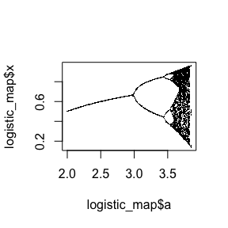

```r
logistic_map = logistic_map_L(0.5, 100, 100, 200:385/100)
plot(logistic_map$a, logistic_map$x, pch = ".")
```

The times taken by each function on a 2025-era MacBook Pro are as follows:

| Call | Method | Median runtime |
| --- | --- | --- |
| `logistic_map_R(0.5, 100, 100, 200:385/100))` | R function | 850 µs |
| `logistic_map_L(0.5, 100, 100, 200:385/100))` | Lua function | **80 µs** |
| `logistic_map_C(0.5, 100, 100, 200:385/100))` | C++ function | 100 µs |

The version written in Lua is around 10 times faster than the version in R, and even somewhat outperforms **Rcpp**. Note that the relative speed of Lua versus C++ depends on the number of iterations, and whether you use **Rcpp** or **cpp11**, which each seem to have marginal advantages in different cases. Nonetheless, the Lua version seems to execute about as quickly as the C++ version, within plus or minus 20%.

The speedup of the Lua function relative to R was much more notable in an earlier test where the R version first created the data frame and then performed the iteration, i.e. with the line `result$x[j] = x` instead of `result_x[j] = x`. The median runtime for that R version was two orders of magnitude slower than the Lua version; the extra overhead associated with `data.frame` methods was pointed out by Tim Taylor. This goes to show that when aiming for efficient R code, it helps to know a few tricks.

## Example 3: Lorenz attractor

Even greater speedups can be seen when conducting more intensive calculations. For example, solving a system of ordinary differential equations (ODEs) is a common scientific task. Normally this is done in R using a general-purpose package such as [**deSolve**](https://CRAN.R-project.org/package=deSolve). In this benchmark we will instead do simple Euler integration of the famous chaotic [Lorenz system](https://en.wikipedia.org/wiki/Lorenz_system).

To calculate this system entirely in R, you might write something like the following:

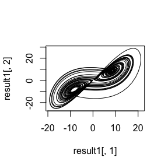

```r
# Lorenz attractor in R

# Take a single step, size dt, of the Lorenz system
step1 = function(x, rho, sigma, beta, dt)
{
    dx = sigma * (x[2] - x[1])
    dy = x[1] * (rho - x[3]) - x[2]
    dz = x[1] * x[2] - beta * x[3]
    x[1] = x[1] + dx * dt
    x[2] = x[2] + dy * dt
    x[3] = x[3] + dz * dt
    return (x)
}

# Calculate Lorenz system trajectory
lorenz1 = function(n, init, rho, sigma, beta)
{
    x = init
    result = matrix(0, nrow = n, ncol = 3)
    for (i in 1:n) {
        result[i, ] = x
        x = step1(x, rho, sigma, beta, 0.01)
    }
    return (result)
}

# Generate and plot result
result1 = lorenz1(5000, c(1,1,1), 28, 10, 8/3)
plot(result1[,1], result1[,2], type = "l")
```

Similar code can be written entirely in Lua using **luajr**:

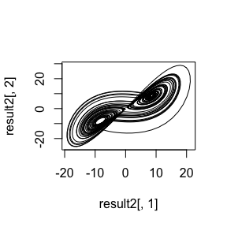

```r
# Lorenz attractor in Lua
library(luajr)

lorenz2 = lua_func("
function(n, init, rho, sigma, beta)
    local step2 = function(x, rho, sigma, beta, dt)
        local dx = sigma * (x[2] - x[1])
        local dy = x[1] * (rho - x[3]) - x[2]
        local dz = x[1] * x[2] - beta * x[3]
        x[1] = x[1] + dx * dt
        x[2] = x[2] + dy * dt
        x[3] = x[3] + dz * dt
        return x
    end

    local x = init
    local result = luajr.matrix(n, 3)

    for i = 1,n do
        result[i] = x[1]
        result[i + n] = x[2]
        result[i + 2*n] = x[3]
        x = step2(x, rho, sigma, beta, 0.01)
    end

    return result
end", "native auto native")

result2 = lorenz2(5000, c(1,1,1), 28, 10, 8/3)
plot(result2[,1], result2[,2], type = "l")
```

Execution times are as follows:

| Call | Method | Median runtime |
| --- | --- | --- |
| `lorenz1(5000, c(1, 1, 1), 28, 10, 8/3)` | R function | 3300 µs |
| `lorenz2(5000, c(1, 1, 1), 28, 10, 8/3)` | Lua function | **38 µs** |

The Lua code is 85 times faster than the equivalent R code.

As mentioned before, a library such as **deSolve** is normally used to integrate systems of ODEs and both versions above do execute rather quickly anyway – it may not be worth the trouble here to save 3 milliseconds! But for intensive and complex simulations, it may help to get a substantial speed boost over what base R can do.